# Using NumPy arrays with one-dimensional data

## What is NumPy?

Numerical Python (NumPy) is a Python library providing a fast and space-efficient data structure: the `ndarray`, a **homogeneous** array structure, indexed with integers. The official documentation is [here](http://www.numpy.org/).

## Creating arrays

You can create an empty array. Simply import numpy and use following constructors: `array`, `arange`, `ones`, `zeros` or `empty`.

```python
import numpy as np # Everybody uses np as shorthand...
# Now we can create arrays from any sequence-like object:
L = [10, 5, 6, 8, -2]
T = (10, 5, 6, 9, -2)
a = np.array(L)
b = np.array(T)
print a
print b
```

```
[10  5  6  8 -2]
[10  5  6  9 -2]
```

```python
# If you create it with empty, the values are arbitrary (not random, not necessarily zero).
nothing = np.empty(10)
nothing
```

```
array([  0.00000000e+000,   0.00000000e+000,   2.15910223e-314,
         2.15456018e-314,   2.15281451e-314,   2.15455383e-314,
         7.20100688e+252,   0.00000000e+000,   2.15237976e-314,
         1.49175550e+195])
```

You can create arrays based on the lenght of other arrays, e.g. with the `ones_like` function.

```python
#Create an array of ones with the same lenght as this one:
L = [2, 3, 4, 6, 4, 3, 2]
b = np.ones(len(L))
a = np.ones_like(L)
a
```

```
array([1, 1, 1, 1, 1, 1, 1])
```

You can also create ranges with `arange`.

```python
# Create an array with the even numbers
# between (and including) 200 and 250.
a = np.arange(200, 251, 2)
a
```

```
array([200, 202, 204, 206, 208, 210, 212, 214, 216, 218, 220, 222, 224,
       226, 228, 230, 232, 234, 236, 238, 240, 242, 244, 246, 248, 250])
```

The function [linspace](http://docs.scipy.org/doc/numpy/reference/generated/numpy.linspace.html) allows for controlling the amount of numbers to generate.

```python
np.linspace(2.0, 3.0, num=5)
```

```
array([ 2.  ,  2.25,  2.5 ,  2.75,  3.  ])
```

## Arrays have types

The `dtype` attribut of an array returns the type of its elements.

```python
ones = np.ones(5)
print type(ones[0])
print ones
print ones.dtype
print ones.itemsize
```

```
<type 'numpy.float64'>
[ 1.  1.  1.  1.  1.]
float64
8
```

NumPy arrays have a single element type for all its values.

```python
L = [1, 4.6, 5]
a = np.array(L)
print a.dtype
```

```
float64
```

We can **explicitly** indicate the type we want for a NumPy array.

```python
#What happened with the numbers?
L = [1, 4.6, 5]
a = np.array(L, dtype="int32")
print a.dtype
print a
```

```
int32
[1 4 5]
```

NumPy element types are not the same as the standard data types of Python.

```python
L = ["this", "is", "an", "array555rrrr"]
a = np.array(L)
print a.dtype
#TODO: Now interpret the type... look in the documentation of NumPy data types.
```

```
|S12
```

You can convert the type of an array using `as_type` operation.

```python
#Convert form float to int with astype:
a = np.array([5.7, 4.2, 3.0])
b = a.astype(np.int32)
print b

#Try to convert this array of strings to some kind of integer array:
a = np.array(["23", "12", "nan", "32", "10"])
print a
b = a.astype(np.int32)
```

```
[5 4 3]
['23' '12' 'nan' '32' '10']
```

```
---------------------------------------------------------------------------
ValueError                                Traceback (most recent call last)
<ipython-input-13-e02f6be3beec> in <module>()
      7 a = np.array(["23", "12", "nan", "32", "10"])
      8 print a
----> 9 b = a.astype(np.int32)

ValueError: invalid literal for int() with base 10: 'nan'
```

## Vectorization!

In general, operations of arrays with scalars are **vectorized**, i.e. they are applied to each element.

```python
x = np.ones(10)
x = x*2
print x
```

```
[ 2.  2.  2.  2.  2.  2.  2.  2.  2.  2.]
```

And if we apply operation between arrays of the same shape (size) they are applied element-wise.

```python
y = np.ones(10)
y + x
```

```
array([ 3.,  3.,  3.,  3.,  3.,  3.,  3.,  3.,  3.,  3.])
```

```python
# Arrays need to be same size:
z = np.ones(5)
x+z
```

```
---------------------------------------------------------------------------
ValueError                                Traceback (most recent call last)
<ipython-input-16-43e069923f90> in <module>()
      1 # Arrays need to be same size:
      2 z = np.ones(5)
----> 3 x+z

ValueError: operands could not be broadcast together with shapes (10,) (5,)
```

Now an exercise!

```python
# create an array of 20 numbers between 5 and 10 using a gamma distribution, print them
# and later increase them in a 20% (you have to find the numpy function for that in the docs)
shape, scale = 2., 2. # mean and dispersion
r = np.random.gamma(shape, scale, 20)
print r
r = r*1.2
print r
```

```
[  2.53498065   3.11970165   5.58191065   4.71504441   5.67202995
   0.80931232   4.36671694   3.47901643   0.79246341   2.99218103
   1.47131787   2.59992197   2.06105961   1.96671269  11.2562569
   4.70161732   4.01701562   4.23482222   8.85013286   2.48605036]
[  3.04197678   3.74364198   6.69829278   5.6580533    6.80643594
   0.97117479   5.24006033   4.17481972   0.95095609   3.59061724
   1.76558144   3.11990637   2.47327153   2.36005523  13.50750828
   5.64194078   4.82041874   5.08178666  10.62015944   2.98326043]
```

## Basic graphing

You can use matplotlib as usual. Now let's generate more random numbers.

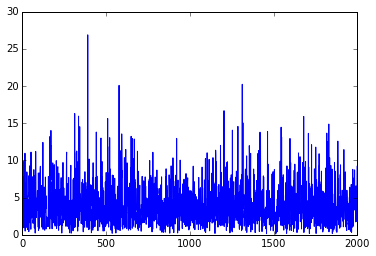

```python
import matplotlib.pyplot as plt
%matplotlib inline
#Re-generate the previous array but with 2000 elements and plot it
r = np.random.gamma(shape, scale, 2000)
plt.plot(r)
```

But for plotting the histogram, you need to do it other way...

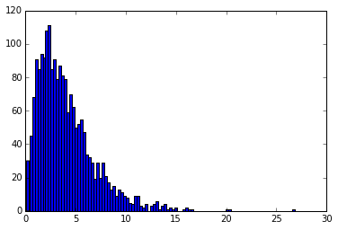

```python
# TODO: Search in the docs of the pyplot object a way to plot a histogram.
# You should particularly read what "bins" are as this influence the plotting of histograms.
plt.hist(r, bins=100)
```

Check if this looks like a Gamma distribution with the given parameters :-)

## Using statistical libraries: analysis of variance

Create three arrays of the same size, two with a Gamma distribution, and one with an exponential distribution. Print their variances.

```python
#Create three arrays of 200 random elements, two with Gamma and one exponential.
# Print variances.
a = np.random.gamma(0.25, 0.3, 200)
b = np.random.gamma(0.3, 0.35, 200)
c = np.random.exponential(0.7, 200)
print a.var(), b.var(), c.var(), b.var()
```

```
0.0128581423478 0.0633925337635 0.579257706964 0.0633925337635
```

And now let's do the analysis of variance.

```python
# Check analysis of variance between each pair of arrays and comment the results.
# Note and read the assumptions of ANOVA, to see if they fit in this case.
from scipy.stats import kruskal
# In the first case, the p-value is relatively high which means they do not have different medians.
h_val, p_val = kruskal(a, b)
print h_val, p_val
# In the second case, the p-value is very low, which means we reject the null hypothesis that
# they come from the same population...
h_val, p_val = kruskal(b, c)
print h_val, p_val
```

```
2.33323391521 0.126638543799
188.326650374 7.37217122698e-43
```

Now do the same check with two random samples normally distributed...

## Indexing and slicing

You can index and slice numpy arrays just as you do with Python lists. If you assign a value to an slice, it gets propagated to all the cells.

```python
#Create an array of ten ones, then slice the second half and set all the elements
#in the slice to zero.
o = np.ones(10)
print o
o[5:]=0
print o
```

```
[ 1.  1.  1.  1.  1.  1.  1.  1.  1.  1.]
[ 1.  1.  1.  1.  1.  0.  0.  0.  0.  0.]
```

A very important aspect of slicing is that **it creates views, not copies**

```python
#Create a slice of the four elements in the middle of the above array
# and use a new variable to reference it.
# Then assign the value 2 to the new reference and print the original.
sl = o[3:7]
print sl
sl[:] = 4
print sl
z = sl.copy()
print o
print z
```

```
[ 1.  1.  0.  0.]
[ 4.  4.  4.  4.]
[ 1.  1.  1.  4.  4.  4.  4.  0.  0.  0.]
[ 4.  4.  4.  4.]
```

## Boolean arrays

You can use boolean expressions to get boolean arrays.

```python
# Assign scores in a class of 15 students for two assignments.
# Create two arrays with the scores of the students using a normal distribution.
assig1 = np.random.normal(5, 2, 15)
assig2 = np.random.normal(5, 2, 15)

#TODO Round all the scores to one decimal.
assig1 = assig1.round(1)
assig2 = assig2.round(1)
print assig1
print assig2
```

```
[-0.3  6.1  0.9  1.2  6.4  4.6  4.8  5.8  2.8  3.9  5.7  6.6  3.9  0.9  3.6]
[ 3.6  6.4  4.4  8.5  4.9  3.1  8.7  7.4  5.8  3.6  1.7  4.4  7.3  4.8  5.4]
```

```python
assig1 >= 5
```

```
array([False,  True, False, False,  True, False, False,  True, False,
       False,  True,  True, False, False, False], dtype=bool)
```

```python
# Now let's think that only the students that passed the first assignment will
# have the second considered.
# Get a boolean array for the students that passed the first assignement.
passed1 = assig1 >= 5.0
print passed1

# Now get the mean of the two assignments per each of the students that passed the first one.
print ((assig2+assig1)/2)[passed1]
```

```
[False  True False False  True False False  True False False  True  True
 False False False]
[ 6.25  5.65  6.6   3.7   5.5 ]
```

## Playing with ufuncs

Universal functions (ufuncs) are vectorized operations on NumPy arrays. Let's plot some functions implemented with ufuncs. The complete list is here: http://docs.scipy.org/doc/numpy/reference/ufuncs.html

```
50
```

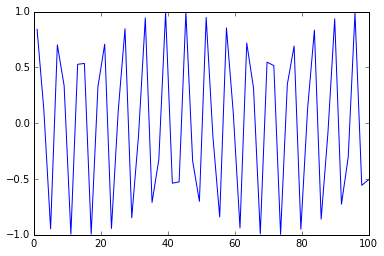

```python
import numpy as np
#TODO: Create an array of 50 elements between 1 and 100 using linspace. Look
# at the documentation of this function.
x = np.linspace(1, 100)
print len(x)

# Get the sin of each of the generated points and plot them.
y = np.sin(x)
plt.plot(x,y)
```

You can plot several arrays in the same plot.

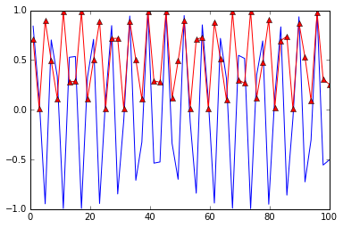

```python
# TODO: Plot the same as above, plus the square of the sin values.
# Look in the docs how you can pass more than one array to plot, and how to draw the second
# with a different color, e.g. red.
plt.plot(x, y, x, y**2, 'r-^')
```

You can also generate random points and do scaterplotting

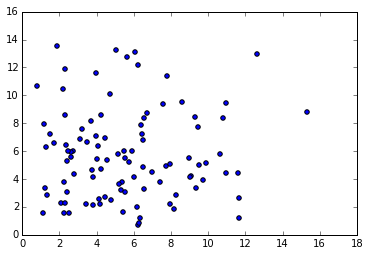

```python
#TODO: generate two arrays of the same size using a random generator with gamma dstribution.
a = np.random.gamma(3,2, 100)
b = np.random.gamma(3,2, 100)

# Plot the two arrays as a scatterplot.
plt.scatter(a,b)
```

Summarization operations are implemented also.

```python
b.mean()
```

```
5.7569014324324961
```

```python
np.sqrt(b)
```

```
array([ 2.29451517,  2.68185694,  3.26844106,  2.66681853,  2.21745631,
        1.09822004,  1.75877462,  1.47059447,  2.88855154,  2.15501156,
        3.05635122,  2.60618584,  2.27648893,  3.48481865,  2.44702767,
        1.98648765,  2.56009859,  2.7513589 ,  1.61894657,  3.40171749,
        1.24903982,  2.80598975,  3.44838726,  2.20876112,  2.16668617,
        2.81907854,  2.04922821,  1.48109401,  1.79840739,  2.5241935 ,
        3.61934755,  1.93843332,  1.75546143,  3.07325085,  2.447633  ,
        2.04352114,  2.53897815,  1.48541458,  2.22997541,  2.57782329,
        1.64078383,  1.57988002,  2.45658254,  2.93265677,  1.95338718,
        3.17223053,  2.90074778,  2.28935561,  2.09673386,  3.37707288,
        1.59361295,  2.89652128,  3.68138133,  1.26597322,  2.7824978 ,
        2.35880388,  2.11692286,  2.51577327,  0.81935651,  2.3186259 ,
        3.08699829,  1.51255862,  2.68543717,  1.09764592,  1.6844225 ,
        3.59925627,  2.25748773,  3.23802286,  1.95395722,  2.95633342,
        2.93625315,  2.32617592,  2.03392772,  2.34382265,  2.85699165,
        1.83908551,  2.04021261,  1.2478434 ,  2.39932358,  1.23935039,
        1.42165506,  1.36100834,  1.4780206 ,  1.83499009,  2.08428198,
        3.64022463,  0.92872133,  1.80802369,  2.63875138,  1.50019783,
        2.96708317,  2.43162158,  2.10243145,  1.90318864,  2.62128329,
        2.34500612,  1.6892592 ,  3.57170611,  2.40535136,  2.45194642])
```

This is a key reference: http://wiki.scipy.org/Numpy_Example_List